# An Analysis of Indicators affecting Consumer Price Index of Turkey

Umut Mete Saka

## Introduction

The Consumer Price Index (CPI) is a measure of the average change over time in the prices paid by urban consumers for a market basket of consumer goods and services. It is calculated and officially announced monthly by Turkish Statistical Institute (TURKSTAT). Consumer price index is used to calculate the inflation over the currency and here in this homework, it is Turkish Lira(TRY).

Economic theories claim that there is a negative correlation between CPI and unemployment rate. In contrary there is a positive correlation between CPI and government spending, claims the theories. Also specifically for Turkey, it has been seen that increase in exchange rates of foreign currencies (mainly EUR and USD) causes inflation in Turkey. Thus, it has a positive correlation between CPI.

Another less common case in economic studies is Stagflation which happens when both CPI and unemployment rises due to secondary indicators.

This homework is to visualize and analyze the monthly data of Government Spending, Unemployment Rate, Exchange Rates and CPI of Turkey between Jan 2010 and Dec 2019 and interpret the effects of the selected indicators over CPI.

The data used in this study is provided from Turkish Republic Central Bank Electronic Data Delivery System from the [link](https://evds2.tcmb.gov.tr/)

## First Steps

#### Loading Packages

I used several packages in my study therefore I started with downloading them. These packages will be needed to import, analyze and visualize my data.

```r
library(data.table)
library(zoo)
library(xts)
library(readxl)
library(ggplot2)
library(stats)
```

#### Importing data and converting into data.table

```r
data_unemp<-data.table(read_xlsx("unemp_mon.xlsx"))
data_exc_rates<-data.table(read_xlsx("usd_eur_mon.xlsx"))
data_cpi<-data.table(read_xlsx("CPI_mon.xlsx"))
data_bud_sp<-data.table(read_xlsx("bud_spe_mon.xlsx"))
```

#### Creating the Currency Basket

Since the most common foreign currencies used in Turkey are EUR and USD, I wanted to use them both by a common method, called currency basket. Here I create currency basket rate as 0.5 EUR + 0.5 USD

```r
data_exc_basket<-data_exc_rates[,list(Currency_Basket_Rate = sum(`TP DK USD A YTL`, `TP DK EUR A YTL`)/2)
                                ,by=list(Tarih)]
```

#### Merging the data into one table

```r
temp<-merge(data_exc_basket,data_unemp)
temp<-merge(temp,data_bud_sp)
all_data<-merge(temp,data_cpi)
```

#### Setting the column names of my table and checking it

```r
setnames(all_data,names(all_data),c("Date","Currency_Basket_Rate","Unemployment_Rate","Government_Spending","Consumer_Price_Index"))

head(all_data)
```

```
##       Date Currency_Basket_Rate Unemployment_Rate Government_Spending
## 1: 2010-01             1.781795              13.6            22189515
## 2: 2010-02             1.784747              13.5            22378223
## 3: 2010-03             1.801911              12.8            22558601
## 4: 2010-04             1.743621              11.3            25128825
## 5: 2010-05             1.737157              10.3            18209701
## 6: 2010-06             1.744170               9.9            22701426
##    Consumer_Price_Index
## 1:               174.07
## 2:               176.59
## 3:               177.62
## 4:               178.68
## 5:               178.04
## 6:               177.04
```

#### Converting Government Spending Data from Thousands of TRY into billions of TRY

```r
all_data$Government_Spending<-all_data$Government_Spending/1e6
```

#### Converting the data into extended time series

```
To have the time index proper I had to add day as 01 to the Date objects.
```

```r
all_data$Date <- as.Date(paste(all_data$Date,"01",sep="-"))
data_xts<- as.xts(all_data)
```

## Analysis

### Meeting with the data

#### Plotting the data

My data is in time series class now and I can start my analysis. First I will plot the data in order to visualize its pattern which will help me to detect time influence on the variables.

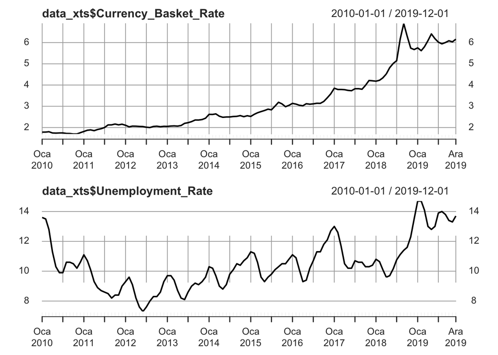

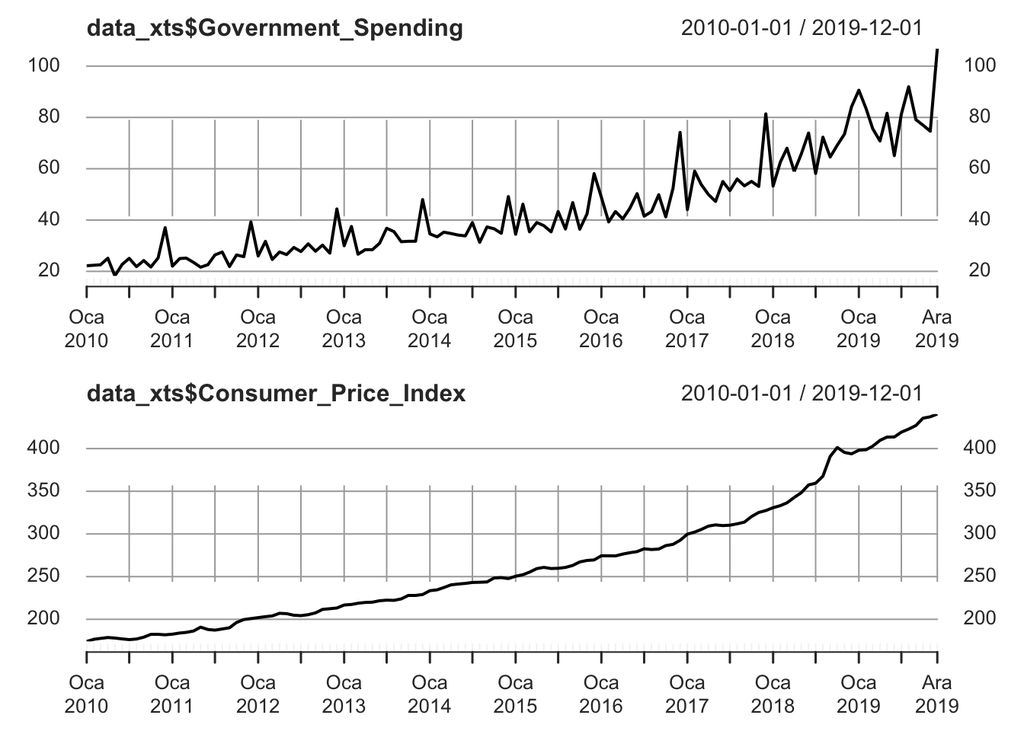

#### Interpreting the plots

As next, I will calculate descriptive statistics of the data to see overall picture regardless of the time.

#### Summarizing my data and analyzing its descriptive statistics

Showing min, max, mean, median and quantiles of the data set by summary function.

```
##      Index            Currency_Basket_Rate Unemployment_Rate
##  Min.   :2010-01-01   Min.   :1.694        Min.   : 7.30
##  1st Qu.:2012-06-23   1st Qu.:2.064        1st Qu.: 9.30
##  Median :2014-12-16   Median :2.621        Median :10.30
##  Mean   :2014-12-16   Mean   :3.174        Mean   :10.46
##  3rd Qu.:2017-06-08   3rd Qu.:3.809        3rd Qu.:11.14
##  Max.   :2019-12-01   Max.   :6.896        Max.   :14.70
##  Government_Spending Consumer_Price_Index
##  Min.   : 18.21      Min.   :174.1
##  1st Qu.: 28.28      1st Qu.:206.3
##  Median : 37.66      Median :249.6
##  Mean   : 44.03      Mean   :267.4
##  3rd Qu.: 54.14      3rd Qu.:310.3
##  Max.   :106.87      Max.   :440.5
```

Showing standart deviation of the data

```r
sqrt(data.frame(var(data_xts$Currency_Basket_Rate),
var(data_xts$Unemployment_Rate),
var(data_xts$Government_Spending),
var(data_xts$Consumer_Price_Index),row.names = "St. Deviation"))
```

```
##               Currency_Basket_Rate Unemployment_Rate Government_Spending
## St. Deviation             1.415137          1.657064            19.31514
##               Consumer_Price_Index
## St. Deviation             74.78465
```

To illustrate the dependence between variables, I calculate covariance and correlation coefficients between CPI and the selected variables.

```
##                      Consumer_Price_Index
## Currency_Basket_Rate            103.89264
## Unemployment_Rate                82.25593
## Government_Spending            1360.98440
## Consumer_Price_Index           5592.74429
```

Showing correlation coefficients of the data with CPI.

```
##                      Consumer_Price_Index
## Currency_Basket_Rate            0.9816889
## Unemployment_Rate               0.6637666
## Government_Spending             0.9421992
## Consumer_Price_Index            1.0000000
```

#### Creating Scatter plots

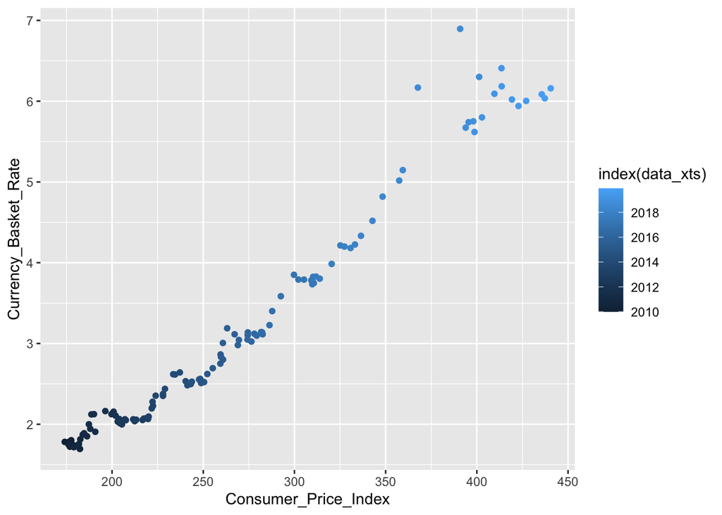

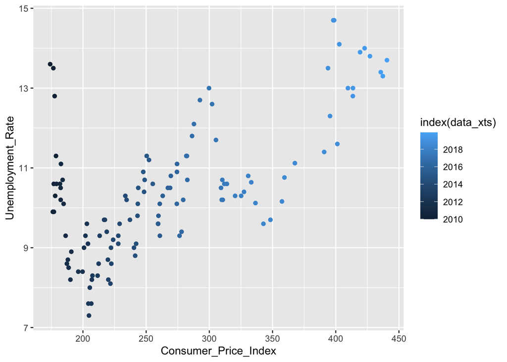

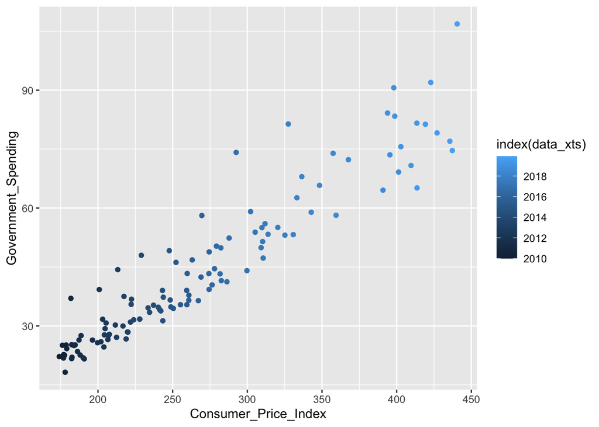

#### Plotting Auto-Correlation functions of the data

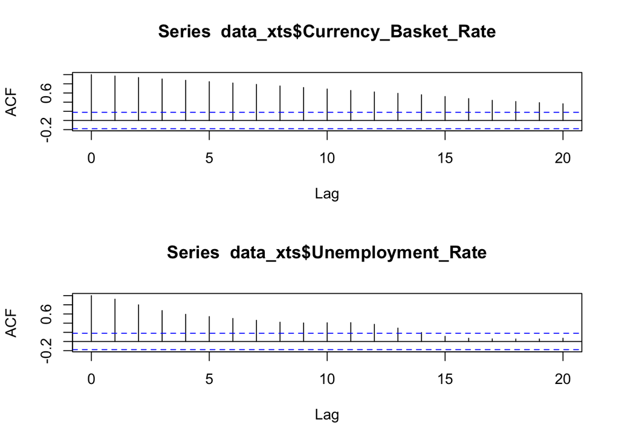

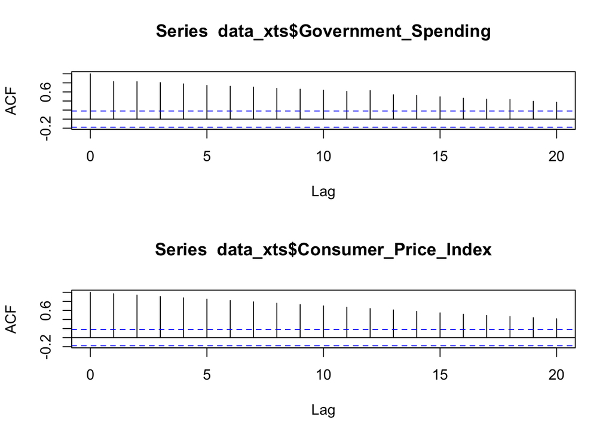

#### Interpreting the plots and the statistics

CPI has high correlation between Government spending and Currency rate. This can be seen in the scatter plots too. This what I expected in the beginning of the study.

The auto-correlation function shows me that both data are highly auto-correlated with k up to 15-lags in Unemployment and 20 in others..

But the unemployment rate shows a behavior which I did not expect. The correlation was positive which I expected it to be negative. Therefore I check the scatter plot. Between years 2010-12 Unemployment and CPI seems to have negative correlation, then slightly positive between 2012-15 than negative between 2015-17 and highly positive between 2018-2019. I will check these in further analysis part.

### Further Analysis over the data

After analysis of the original set, I will make some specific analysis to have better results. My first approach it to smooth the data on a 12-month base. The second approach is to take the logarithm of the variables, which is most often applied to economic data sets. The third approach is to de-trend data sets by differencing.

#### Plots of the data with moving average with k = 12

The data has fluctuations over time so I smoothed the data by taking 12 month moving average and plotted.

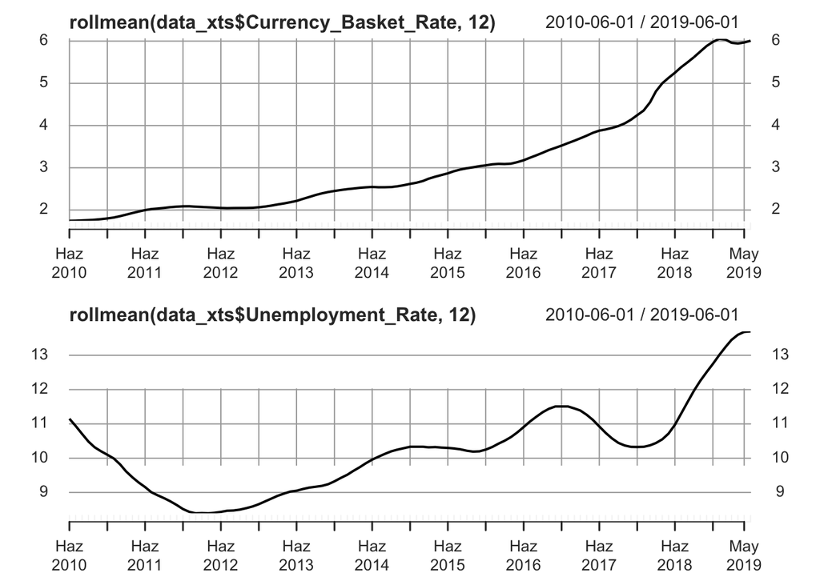

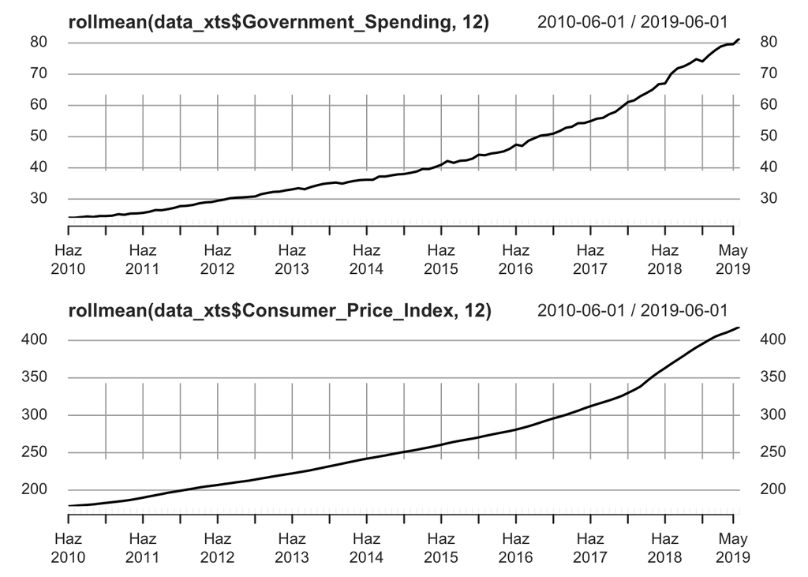

We see that impact of the smoothing cancel the seaonality effect but trend remains persistent.

#### Taking log of the data

To visualize the major changes in more linear terms, I plotted log transformation of the data.

```r
log_data_xts <- log(data_xts)
```

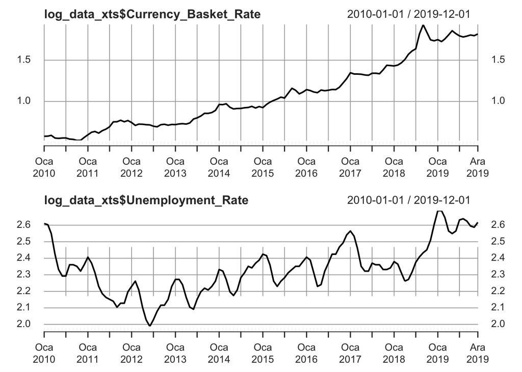

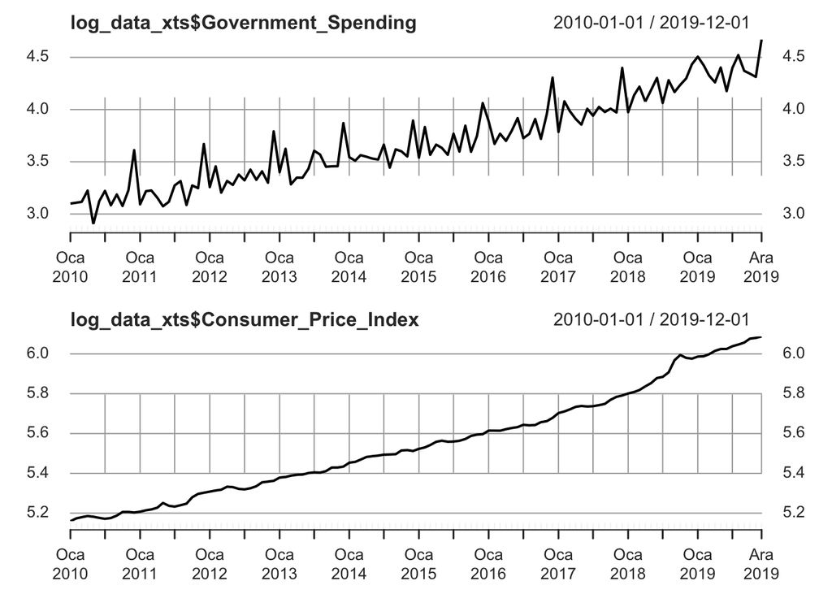

#### Calculating the difference of the data

Detrending the series with taking differences, both for original and log-transformed series, summarizing their statistics and plotting

```r
Dif_data_xts <- na.omit(diff(data_xts))
Dif_log_data_xts <- na.omit(diff(log_data_xts))

summary(Dif_data_xts)
```

```
##      Index            Currency_Basket_Rate Unemployment_Rate
##  Min.   :2010-02-01   Min.   :-0.59524     Min.   :-1.5000000
##  1st Qu.:2012-07-16   1st Qu.:-0.02252     1st Qu.:-0.3000000
##  Median :2015-01-01   Median : 0.01709     Median : 0.0000000
##  Mean   :2014-12-31   Mean   : 0.03679     Mean   : 0.0008403
##  3rd Qu.:2017-06-16   3rd Qu.: 0.06751     3rd Qu.: 0.3000000
##  Max.   :2019-12-01   Max.   : 1.02173     Max.   : 1.2000000
##  Government_Spending Consumer_Price_Index
##  Min.   :-30.0953    Min.   :-5.790
##  1st Qu.: -3.7400    1st Qu.: 0.645
##  Median :  0.1804    Median : 1.600
##  Mean   :  0.7116    Mean   : 2.239
##  3rd Qu.:  5.7366    3rd Qu.: 3.450
##  Max.   : 32.2359    Max.   :23.180
```

```r
summary(Dif_log_data_xts)
```

```
##      Index            Currency_Basket_Rate Unemployment_Rate
##  Min.   :2010-02-01   Min.   :-0.093213    Min.   :-1.246e-01
##  1st Qu.:2012-07-16   1st Qu.:-0.007513    1st Qu.:-3.033e-02
##  Median :2015-01-01   Median : 0.007982    Median : 0.000e+00
##  Mean   :2014-12-31   Mean   : 0.010423    Mean   : 6.156e-05
##  3rd Qu.:2017-06-16   3rd Qu.: 0.025782    3rd Qu.: 3.322e-02
##  Max.   :2019-12-01   Max.   : 0.181090    Max.   : 9.309e-02
##  Government_Spending Consumer_Price_Index
##  Min.   :-0.520545   Min.   :-0.014534
##  1st Qu.:-0.095283   1st Qu.: 0.002537
##  Median : 0.008028   Median : 0.006488
##  Mean   : 0.013210   Mean   : 0.007802
##  3rd Qu.: 0.138510   3rd Qu.: 0.012590
##  Max.   : 0.492317   Max.   : 0.061140
```

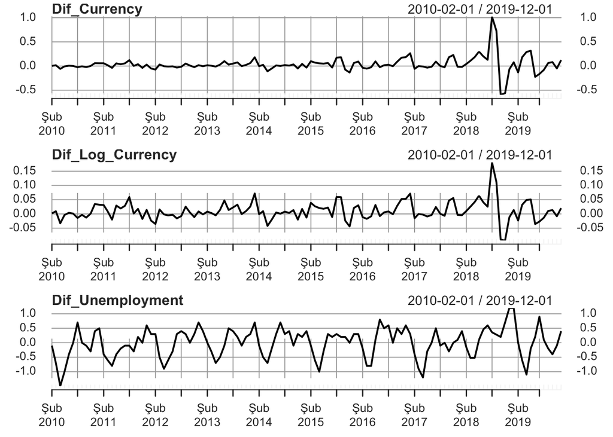

[figure not shown]

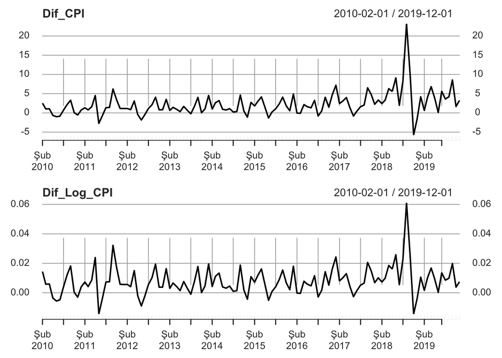

Fluctuations are more appaerent in Difference of log_data.

*In all plots we see that differencing eliminates the trend*

#### Calculating correlation between differenced sets

```
##                      Consumer_Price_Index
## Currency_Basket_Rate           0.49834017
## Unemployment_Rate             -0.02137091
## Government_Spending           -0.11348974
## Consumer_Price_Index           1.00000000
```

#### Calculating lagged data

It can be seen that difference in currency has a correlation with difference in CPI. We can check that whether the increase in currency rate affect CPI after some time, by lagging the CPI data.

```r
lag_cor<-cor(na.omit(lag(Dif_data_xts$Consumer_Price_Index,0)),Dif_data_xts$Currency_Basket_Rate[1:119])

for(i in 1:16){

  lag_cor<-c(lag_cor,cor(na.omit(lag(Dif_data_xts$Consumer_Price_Index,i)),Dif_data_xts$Currency_Basket_Rate[1:(119-i)]))
}

lag_cor
```

```
##  [1] 0.4983402 0.4976974 0.4975376 0.5017052 0.5017770 0.5062072 0.5243719
##  [8] 0.5221143 0.5210305 0.5106844 0.5082101 0.5068599 0.5064664 0.5036445
## [15] 0.4595049 0.6458058 0.4964470
```

By considering 1 to 16 month length on CPI data, it can be seen that the correlation remains around 0.5 and increase for lagged data with a maximum increase in 15 month to 0.64. So it will not be wrong to say that an increase in the currency rate may increase the CPI in further months.

#### Auto-correlation functions of differenced sets

Acf of the differenced sets of the main set

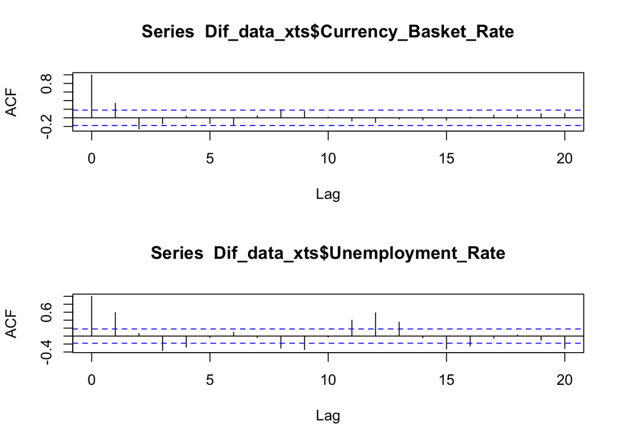

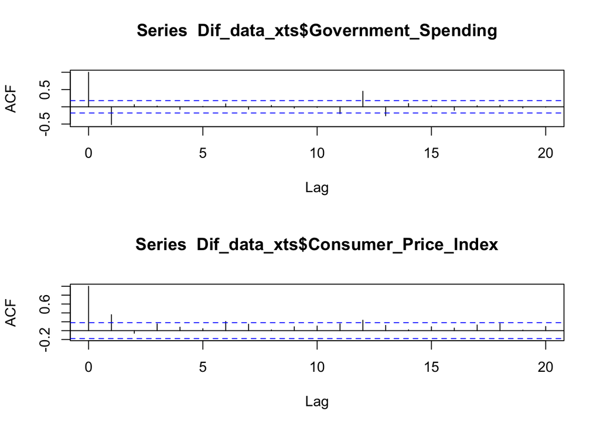

Acf of the differenced sets of the log-transformed set

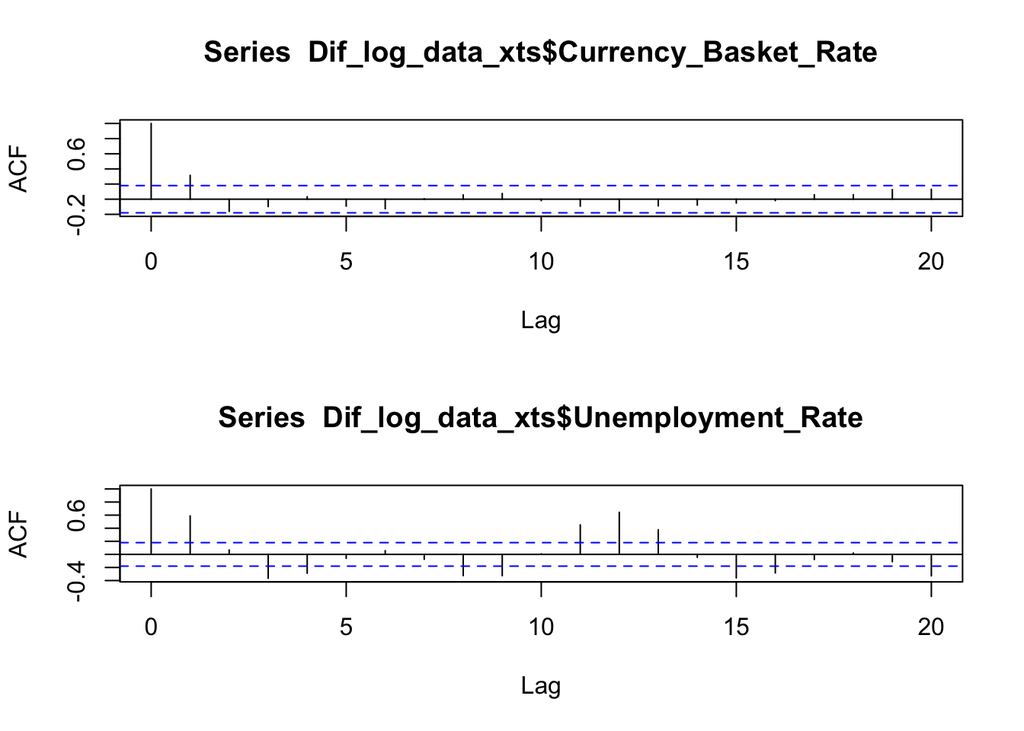

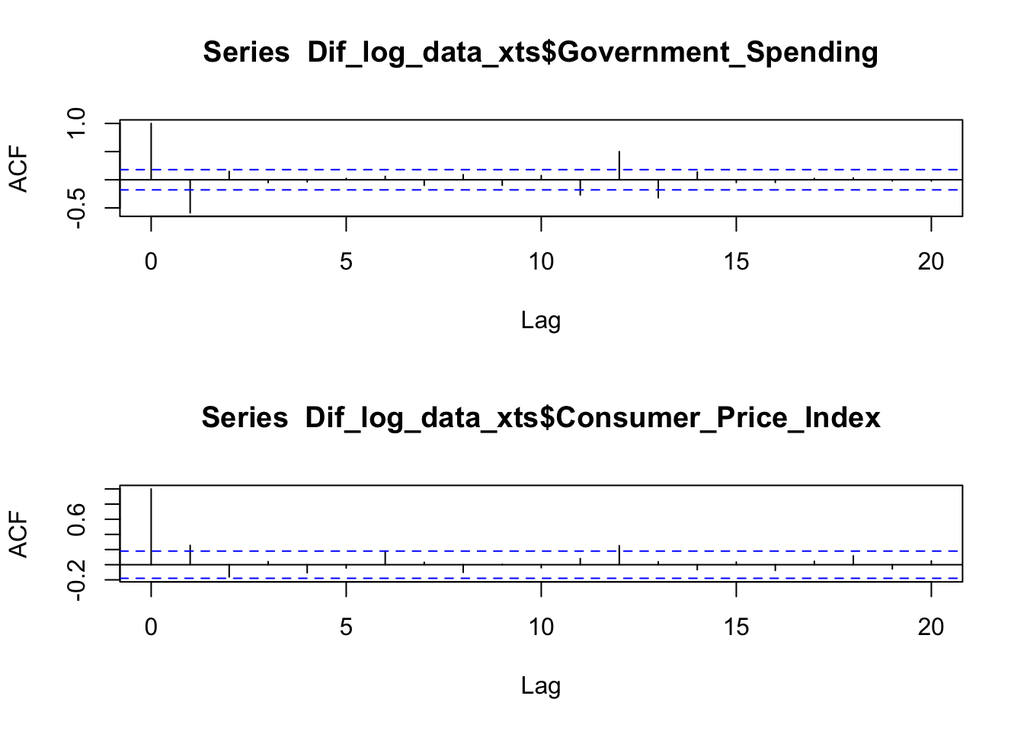

#### Further analysis of Unemployment

The relation between unemployment data and CPI creates some inconsistency in my primary analysis. Therefore I will make further analysis of the data. Firstly I will divide the data to years and calculate correlations between CPI.

```r
data_10 <- data_xts["2010"]
data_11 <- data_xts["2011"]
data_12 <- data_xts["2012"]
data_13 <- data_xts["2013"]
data_14 <- data_xts["2014"]
data_15 <- data_xts["2015"]
data_16 <- data_xts["2016"]
data_17 <- data_xts["2017"]
data_18 <- data_xts["2018"]
data_19 <- data_xts["2019"]
```

```r
#correlation between the data in 2010
cor(data_10$Unemployment_Rate,data_10$Consumer_Price_Index)
```

```
##                   Consumer_Price_Index
## Unemployment_Rate            -0.487578
```

```r
#correlation between the data in 2011
cor(data_11$Unemployment_Rate,data_11$Consumer_Price_Index)
```

```
##                   Consumer_Price_Index
## Unemployment_Rate           -0.6306528
```

```r
#correlation between the data in 2012
cor(data_12$Unemployment_Rate,data_12$Consumer_Price_Index)
```

```
##                   Consumer_Price_Index
## Unemployment_Rate           0.01607006
```

```r
#correlation between the data in 2013
cor(data_13$Unemployment_Rate,data_13$Consumer_Price_Index)
```

```
##                   Consumer_Price_Index
## Unemployment_Rate           0.03430451
```

```r
#correlation between the data in 2014
cor(data_14$Unemployment_Rate,data_14$Consumer_Price_Index)
```

```
##                   Consumer_Price_Index
## Unemployment_Rate            0.3419921
```

```r
#correlation between the data in 2015
cor(data_15$Unemployment_Rate,data_15$Consumer_Price_Index)
```

```
##                   Consumer_Price_Index
## Unemployment_Rate           -0.2356952
```

```r
#correlation between the data in 2016
cor(data_16$Unemployment_Rate,data_16$Consumer_Price_Index)
```

```
##                   Consumer_Price_Index
## Unemployment_Rate            0.7679054
```

```r
#correlation between the data in 2017
cor(data_17$Unemployment_Rate,data_17$Consumer_Price_Index)
```

```
##                   Consumer_Price_Index
## Unemployment_Rate           -0.7205105
```

```r
#correlation between the data in 2018
cor(data_18$Unemployment_Rate,data_18$Consumer_Price_Index)
```

```
##                   Consumer_Price_Index
## Unemployment_Rate            0.7651925
```

```r
#correlation between the data in 2019
cor(data_19$Unemployment_Rate,data_19$Consumer_Price_Index)
```

```
##                   Consumer_Price_Index
## Unemployment_Rate            -0.418441
```

Also it is possible that the unemployment rate of a year, can affect the CPI of a further year so I check correlation of unemployment rate with CPI of following year.

```r
#correlation between the Unemployment data in 2010 and CPI data in 2011
cor(data_10$Unemployment_Rate,data_11$Consumer_Price_Index)
```

```
##                   Consumer_Price_Index
## Unemployment_Rate           -0.6133526
```

```r
#correlation between the Unemployment data in 2011 and CPI data in 2012
cor(data_11$Unemployment_Rate,data_12$Consumer_Price_Index)
```

```
##                   Consumer_Price_Index
## Unemployment_Rate           -0.6074415
```

```r
#correlation between the Unemployment data in 2012 and CPI data in 2013
cor(data_12$Unemployment_Rate,data_13$Consumer_Price_Index)
```

```
##                   Consumer_Price_Index
## Unemployment_Rate           -0.1176454
```

```r
#correlation between the Unemployment data in 2013 and CPI data in 2014
cor(data_13$Unemployment_Rate,data_14$Consumer_Price_Index)
```

```
##                   Consumer_Price_Index
## Unemployment_Rate           -0.2010897
```

```r
#correlation between the Unemployment data in 2014 and CPI data in 2015
cor(data_14$Unemployment_Rate,data_15$Consumer_Price_Index)
```

```
##                   Consumer_Price_Index
## Unemployment_Rate            0.3650974
```

```r
#correlation between the Unemployment data in 2015 and CPI data in 2016
cor(data_15$Unemployment_Rate,data_16$Consumer_Price_Index)
```

```
##                   Consumer_Price_Index
## Unemployment_Rate          0.001796245
```

```r
#correlation between the Unemployment data in 2016 and CPI data in 2017
cor(data_16$Unemployment_Rate,data_17$Consumer_Price_Index)
```

```
##                   Consumer_Price_Index
## Unemployment_Rate            0.6512815
```

```r
#correlation between the Unemployment data in 2017 and CPI data in 2018
cor(data_17$Unemployment_Rate,data_18$Consumer_Price_Index)
```

```
##                   Consumer_Price_Index
## Unemployment_Rate           -0.6614558
```

```r
#correlation between the Unemployment data in 2018 and CPI data in 2019
cor(data_18$Unemployment_Rate,data_19$Consumer_Price_Index)
```

```
##                   Consumer_Price_Index
## Unemployment_Rate            0.7755513
```

## Conclusion

Consumer Price Index of Turkey has a dependency over Currency rates. A difference in the currency affects both the current and the future CPI.

Even though the Government spending seems to have a high positive correlation with CPI, the difference happens in government spending seems to have no effect over CPI.

## Appendix

https://www.bls.gov/cpi/

https://core.ac.uk/download/pdf/7142108.pdf

[Macroeconomics in Context, Goodwin N.,Nelson J.A.,Harris J.](https://www.taylorfrancis.com/books/9781315702735)

[R documentation](https://www.rdocumentation.org/)